# ProjectPart3

## Cancel Culture

Team Members: Allison DeSantis (ajd29), Klara Van Wamelen (klaravw), Sebastian Gonzalez Castro (srg4rv)

### Cancel culture is the phenomenon of collectively shaming an individual (usually a celebrity or public figure) online in response to a controversial thing they said or did. Our goal is to analyze cancel culture in online communities.

#### Our first research question and follow-up question are: Is cancel culture a negative phenomenon? Are there any positive aspects? We analyze this through sentiment analysis of cancel culture tweets and tweets from 'canceled' celebrities.

### Part 1: Twitter

In order to analyze cancel culture tweets about a celebrity, we need to collect tweets that include cancel culture language. We collected data from two incidents of cancel culture in 2019. We chose to analyze James Charles (YouTube beauty guru) and Cardi B (rapper and songwriter), because these celebrities were both canceled in 2019 due to a controversial action.

Importing necessary libraries, like GetOldTweets3 to collect tweets from 2019.

```python
import sys
import GetOldTweets3 as got # needs to be installed
import pandas as pd
import seaborn as sns
import matplotlib.pyplot as plt
from vaderSentiment.vaderSentiment import SentimentIntensityAnalyzer
from nltk import tokenize
```

```python
def get_cancel_tweets(names, count, time):

    post_id = []
    post_text = []
    author = []
    date = []
    retweet = []
    favorites = []
    canceled_celeb = []

    for date_range in time:
        for name in names:
            search = str('cancel ' + name)
            search2 = str(name + 'IsOverParty')

            tweetCriteria = got.manager.TweetCriteria().setQuerySearch(search). \
            setSince(date_range[0]).setUntil(date_range[1]).setMaxTweets(count)

            tweetCriteria2 = got.manager.TweetCriteria().setQuerySearch(search2). \
            setSince(date_range[0]).setUntil(date_range[1]).setMaxTweets(count)

            tweets = got.manager.TweetManager.getTweets(tweetCriteria)
            tweets2 = got.manager.TweetManager.getTweets(tweetCriteria2)

            for tweet in tweets:
                post_id.append(tweet.id)
                post_text.append(tweet.text)
                author.append(tweet.username)
                date.append(tweet.date)
                retweet.append(tweet.retweets)
                favorites.append(tweet.favorites)
                canceled_celeb.append(name)

            for tweet in tweets2:
                post_id.append(tweet.id)
                post_text.append(tweet.text)
                author.append(tweet.username)
                date.append(tweet.date)
                retweet.append(tweet.retweets)
                favorites.append(tweet.favorites)
                canceled_celeb.append(name)

    data = {'post_id':post_id, 'post_text':post_text, 'author':author, 'date':date,
            'retweets':retweet, 'favorites':favorites, 'canceled_celeb':canceled_celeb}

    # data frames to hold tweets
    cancel_tweets = pd.DataFrame(data=data)

    return cancel_tweets
```

```python
names = ['James Charles', 'Cardi B']
dates = [('2019-01-01', '2019-05-01'), ('2019-06-01', '2019-12-31'), ('2020-01-01', '2020-04-27')]
cancel_tweets = get_cancel_tweets(names, 500, dates)
```

Some tweets that contain the word 'cancel' and the celebrites' names cannot actually be considered cancel culture tweets. The celebrities do concerts and tours. We don't care about tweets from fans on social media that pertain to a canceled concert or tour. We drop any tweets from the dataframe that contain the words concert, tour, show, live, or performance. We also drop tweets with duplicate post text from the dataframe and leave the first tweet with the post text. We save the cancel_tweets_clean dataframe to a csv.

```python
# drop tweets with duplicate post text, keep the first one
duplicate_posts = cancel_tweets[cancel_tweets.duplicated(subset='post_text', keep='first')]

no_dups = cancel_tweets.drop(duplicate_posts.index)

# find tweets about concerts, tours, and shows
invalid_cancel_tweets = no_dups[no_dups.post_text.str.contains('concert|show|tour|performance|live')]

# drop tweets from df, likely not cancel culture tweets
cancel_tweets_clean = no_dups.drop(invalid_cancel_tweets.index)

cancel_tweets_clean.to_csv('cancel_tweets_clean.csv')
```

Below, is VADER sentiment analysis of the cancel culture tweets. We want to see what the postive, negative, and neutral scores are for the cancel tweets. Since a tweet can contain multiple sentences, we break up the tweets into sentences using tokenize.sent_tokenize(tweet.post_text) and store a tuple of the sentences and the post that they come from in different lists depending on which celebrity the cancel tweet is about. After storing the sentiment analysis scores in a dataframe for each celebrity, we average the sentiment analysis scores by post.

```python
# lists to hold sentences of tweets about the three celebrities
james_sentences = []
cardi_sentences = []

for i in range(len(cancel_tweets_clean)):

    # store sentences from tweet in sentences
    sentences = tokenize.sent_tokenize(str(cancel_tweets_clean.iloc[i,:].post_text))

    # put (sentences, tweet.post_text) in correct lists
    if (cancel_tweets_clean.iloc[i,:].canceled_celeb=='James Charles'):
        james_sentences.append((sentences, cancel_tweets_clean.iloc[i,:].post_text))
    if (cancel_tweets_clean.iloc[i,:].canceled_celeb=='Cardi B'):
        cardi_sentences.append((sentences, cancel_tweets_clean.iloc[i,:].post_text))

paragraphSentiments = 0.0
analyzer = SentimentIntensityAnalyzer()

scores_james = []
posts_james = []

scores_cardi = []
posts_cardi = []

# sentiment analysis for each celebrity
for post in james_sentences:
    for sentence in post[0]:
        vs = analyzer.polarity_scores(sentence)
        scores_james.append(vs)
        posts_james.append(post[1])

for post in cardi_sentences:
    for sentence in post[0]:
        vs = analyzer.polarity_scores(sentence)
        scores_cardi.append(vs)
        posts_cardi.append(post[1])

# store sentiment analysis score data in dataframes
sent_james = pd.DataFrame(data=scores_james)
sent_james['post_text'] = pd.Series(data=posts_james)

# average sentiment analysis scores by post
james_by_post = sent_james.groupby(['post_text'], as_index=False).mean()

sent_cardi = pd.DataFrame(data=scores_cardi)
sent_cardi['post_text'] = pd.Series(data=posts_cardi)
cardi_by_post = sent_cardi.groupby(['post_text'], as_index=False).mean()
```

We find the statistical summary for each celebrity's sentiment analysis scores that are averaged by post.

```python
james_by_post.describe()
```

|  | neg | neu | pos | compound |
| --- | --- | --- | --- | --- |
| count | 1991.000000 | 1991.000000 | 1991.000000 | 1991.000000 |
| mean | 0.154521 | 0.753325 | 0.092155 | -0.104011 |
| std | 0.138066 | 0.165109 | 0.121212 | 0.352760 |
| min | 0.000000 | 0.000000 | 0.000000 | -0.974900 |
| 25% | 0.048214 | 0.652500 | 0.000000 | -0.296000 |
| 50% | 0.134667 | 0.764500 | 0.048250 | -0.094200 |
| 75% | 0.228667 | 0.867250 | 0.150000 | 0.074667 |
| max | 1.000000 | 1.000000 | 1.000000 | 0.974100 |

```python
cardi_by_post.describe()
```

|  | neg | neu | pos | compound |
| --- | --- | --- | --- | --- |
| count | 1406.000000 | 1406.000000 | 1406.000000 | 1406.000000 |
| mean | 0.137196 | 0.784471 | 0.078319 | -0.099744 |
| std | 0.137128 | 0.163009 | 0.112916 | 0.328729 |
| min | 0.000000 | 0.000000 | 0.000000 | -0.966900 |
| 25% | 0.000000 | 0.683550 | 0.000000 | -0.271922 |
| 50% | 0.111000 | 0.796750 | 0.027600 | -0.067842 |
| 75% | 0.212200 | 0.905000 | 0.124000 | 0.041825 |
| max | 0.804000 | 1.000000 | 1.000000 | 0.918600 |

The statistical analysis summaries show that the sentiment analysis scores do not differ between James Charles and Cardi B that much. The ratios for proportions of text that fall into the positive, negative, and neutral sentiment categories are not too different when comparing the results for the two celebrities. We see that the highest mean score for each celebrity is the neutral category. The mean negative scores are higher than the mean positive scores for both celebrities.

Below, are boxplots of the negative scores averaged by post for each celebrity.

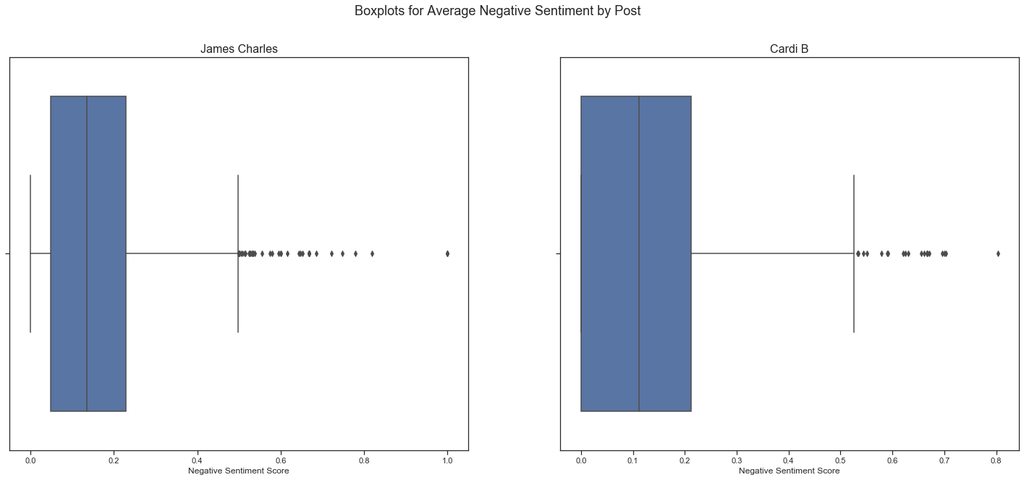

```python
fig, axs = plt.subplots(ncols=2, figsize=(25,10))
fig.suptitle('Boxplots for Average Negative Sentiment by Post', fontsize=18)

ax1 = sns.boxplot(x=james_by_post.neg, ax=axs[0])
ax2 = sns.boxplot(x=cardi_by_post.neg, ax=axs[1])

ax1.set_title('James Charles', fontsize=16)
ax2.set_title('Cardi B', fontsize=16)

ax1.set_xlabel(xlabel='Negative Sentiment Score')
ax2.set_xlabel(xlabel='Negative Sentiment Score')
```

We can see many outliers on each boxplot. So for many posts (tweets), the negative sentiment score is higher than 1.5*IQR.

Next, we plot the date of each post and the post's average negative sentiment score in scatter plots to see if the average negative sentiment score has changed from 1/1/2019 until 4/27/2020.

```python
# merging dataframes to get the dates and the sentiment score by post

cancel_james = cancel_tweets_clean[cancel_tweets_clean['canceled_celeb']=='James Charles']
cancel_cardi = cancel_tweets_clean[cancel_tweets_clean['canceled_celeb']=='Cardi B']

james_date = pd.merge(james_by_post, cancel_james, on='post_text')
james_date['new_date'] = pd.to_datetime(james_date['date']).apply(lambda date: date.toordinal())
james_date = james_date.sort_values(by='new_date')

cardi_date = pd.merge(cardi_by_post, cancel_cardi, on='post_text')
cardi_date['new_date'] = pd.to_datetime(cardi_date['date']).apply(lambda date: date.toordinal())
cardi_date = cardi_date.sort_values(by='new_date')
```

[output not shown]

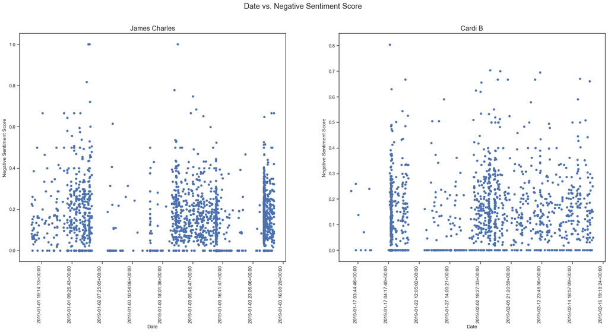

```python
fig, axs = plt.subplots(ncols=2, figsize=(25,10))
fig.suptitle('Date vs. Negative Sentiment Score', fontsize=18)

ax1 = james_date.plot.scatter(x='new_date', y='neg', ax=axs[0])
ax2 = cardi_date.plot.scatter(x='new_date', y='neg', ax=axs[1])

ax1.set_title('James Charles', fontsize=16)
ax2.set_title('Cardi B', fontsize=16)

ax1.set_xticklabels(labels=james_date.date, rotation=90, ha='right')
ax2.set_xticklabels(labels=cardi_date.date, rotation=90, ha='right')

ax1.xaxis.set_major_locator(plt.MaxNLocator(10))
ax2.xaxis.set_major_locator(plt.MaxNLocator(10))

ax1.set_xlabel(xlabel='Date')
ax1.set_ylabel(ylabel='Negative Sentiment Score')
ax2.set_xlabel(xlabel='Date')
ax2.set_ylabel(ylabel='Negative Sentiment Score')
```

We can see that there is no linear relationship between date and negative sentiment score for either of the celebrities. The points, representing tweets, are scattered fairly randomly. So we cannot conclude that the cancel tweets got more or less negative during 2019.

To analyze the sentiment of the canceled celebrities' posts on twitter, we collect a max of 500 tweets from each celebrity twitter account for each date range.

```python
# function to get tweets from the canceled celeb
def get_celeb_tweets(usernames, count, time):
    post_id = []
    post_text = []
    author = []
    date = []
    retweet = []
    favorites = []

    for t in time:
        for username in usernames:

            tweetCriteria = got.manager.TweetCriteria().setUsername(username). \
            setSince(t[0]).setUntil(t[1]).setMaxTweets(count)
            tweets = got.manager.TweetManager.getTweets(tweetCriteria)

            for tweet in tweets:
                post_id.append(tweet.id)
                post_text.append(tweet.text)
                author.append(tweet.username)
                date.append(tweet.date)
                retweet.append(tweet.retweets)
                favorites.append(tweet.favorites)

    data = {'post_id': post_id, 'post_text': post_text, 'author': author,
            'date': date, 'retweets':retweet, 'favorites': favorites}

    celeb_tweets = pd.DataFrame(data=data)

    return celeb_tweets
```

```python
usernames = ['jamescharles', 'iamcardib']
dates = [('2019-01-01', '2019-05-01'), ('2019-06-01', '2019-12-31'), ('2020-01-01', '2020-04-27')]
celeb_tweets = get_celeb_tweets(usernames, 500, dates)
```

To clean the celeb_tweets dataframe, we drop tweets with duplicate post text from the dataframe and leave the first tweet with the post text. We save the celeb_clean dataframe to a csv.

```python
dups = celeb_tweets[celeb_tweets.duplicated(subset='post_text', keep='first')]

celeb_tweets_clean = celeb_tweets.drop(dups.index)

celeb_tweets_clean.to_csv('celeb_tweets_clean.csv')
```

```python
# splitting up dataframe by celebrity
celeb_james = celeb_tweets_clean[celeb_tweets_clean.author=='jamescharles']
celeb_cardi = celeb_tweets_clean[celeb_tweets_clean.author=='iamcardib']
```

Doing VADER sentiment analysis the same as with the cancel tweets.

```python
# lists to hold sentences of tweets about the three celebrities
james_sentences = []
cardi_sentences = []

for i in range(len(celeb_tweets_clean)):

    # store sentences from tweet in sentences
    sentences = tokenize.sent_tokenize(str(celeb_tweets_clean.iloc[i,:].post_text))

    # put (sentences, tweet.post_text) in correct lists
    if (celeb_tweets_clean.iloc[i,:].author=='jamescharles'):
        james_sentences.append((sentences, celeb_tweets_clean.iloc[i,:].post_text))
    if (celeb_tweets_clean.iloc[i,:].author=='iamcardib'):
        cardi_sentences.append((sentences, celeb_tweets_clean.iloc[i,:].post_text))

paragraphSentiments = 0.0
analyzer = SentimentIntensityAnalyzer()

scores_james = []
posts_james = []

scores_cardi = []
posts_cardi = []

# sentiment analysis for each celebrity
for post in james_sentences:
    for sentence in post[0]:
        vs = analyzer.polarity_scores(sentence)
        scores_james.append(vs)
        posts_james.append(post[1])

for post in cardi_sentences:
    for sentence in post[0]:
        vs = analyzer.polarity_scores(sentence)
        scores_cardi.append(vs)
        posts_cardi.append(post[1])

# store sentiment analysis score data in dataframes
sent_james = pd.DataFrame(data=scores_james)
sent_james['post_text'] = pd.Series(data=posts_james)

# average sentiment analysis scores by post
james_by_post = sent_james.groupby(['post_text'], as_index=False).mean()

sent_cardi = pd.DataFrame(data=scores_cardi)
sent_cardi['post_text'] = pd.Series(data=posts_cardi)
cardi_by_post = sent_cardi.groupby(['post_text'], as_index=False).mean()
```

```python
james_by_post.describe()
```

|  | neg | neu | pos | compound |
| --- | --- | --- | --- | --- |
| count | 1423.000000 | 1423.000000 | 1423.000000 | 1423.000000 |
| mean | 0.074774 | 0.735273 | 0.189952 | 0.158225 |
| std | 0.156891 | 0.250625 | 0.237359 | 0.374704 |
| min | 0.000000 | 0.000000 | 0.000000 | -0.947700 |
| 25% | 0.000000 | 0.573500 | 0.000000 | 0.000000 |
| 50% | 0.000000 | 0.773000 | 0.096000 | 0.024833 |
| 75% | 0.079000 | 1.000000 | 0.310000 | 0.440400 |
| max | 1.000000 | 1.000000 | 1.000000 | 0.970100 |

```python
cardi_by_post.describe()
```

|  | neg | neu | pos | compound |
| --- | --- | --- | --- | --- |
| count | 1000.000000 | 1000.000000 | 1000.000000 | 1000.000000 |
| mean | 0.091203 | 0.769016 | 0.139782 | 0.035251 |
| std | 0.164922 | 0.237679 | 0.207465 | 0.404615 |
| min | 0.000000 | 0.000000 | 0.000000 | -0.988300 |
| 25% | 0.000000 | 0.624125 | 0.000000 | -0.124287 |
| 50% | 0.000000 | 0.811500 | 0.000000 | 0.000000 |
| 75% | 0.132000 | 1.000000 | 0.213000 | 0.318200 |
| max | 1.000000 | 1.000000 | 1.000000 | 0.984100 |

The average negative sentiment score is low for tweets from James Charles and Cardi B. For both celebrities, the average neutral sentiment score is the highest when comparing negative, positive, and neutral sentiment scores.

Next, we plot the boxplots for average negative sentiment and average positive sentiment by post.

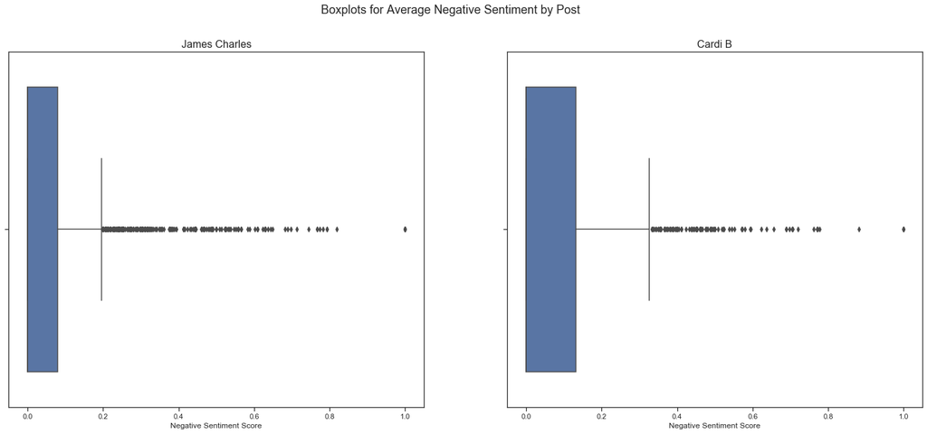

```python
fig, axs = plt.subplots(ncols=2, figsize=(25,10))
fig.suptitle('Boxplots for Average Negative Sentiment by Post', fontsize=18)

ax1 = sns.boxplot(x=james_by_post.neg, ax=axs[0])
ax2 = sns.boxplot(x=cardi_by_post.neg, ax=axs[1])

ax1.set_title('James Charles', fontsize=16)
ax2.set_title('Cardi B', fontsize=16)

ax1.set_xlabel('Negative Sentiment Score')
ax2.set_xlabel('Negative Sentiment Score')
```

We can see that there are many outliers on the boxplot for average negative sentiment score for each post.

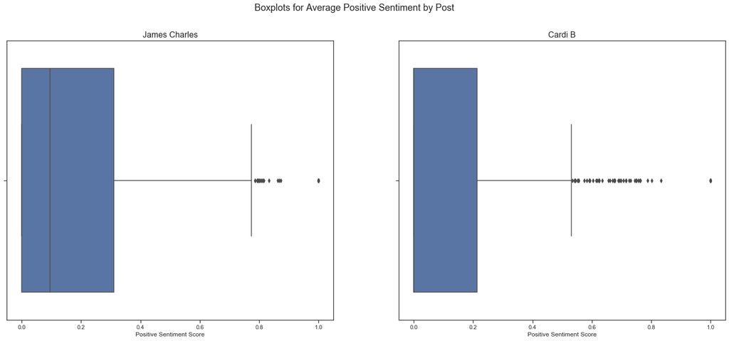

```python
fig, axs = plt.subplots(ncols=2, figsize=(25,10))
fig.suptitle('Boxplots for Average Positive Sentiment by Post', fontsize=18)

ax1 = sns.boxplot(x=james_by_post.pos, ax=axs[0])
ax2 = sns.boxplot(x=cardi_by_post.pos, ax=axs[1])

ax1.set_title('James Charles', fontsize=16)
ax2.set_title('Cardi B', fontsize=16)

ax1.set_xlabel('Positive Sentiment Score')
ax2.set_xlabel('Positive Sentiment Score')
```

We can see that the boxplots for positive sentiment score have a much larger IQR but still have many outliers on the upper end, especially for Cardi B.

Next, we plot the date and average negative sentiment by post for both celebrities.

```python
# merging dataframes to get the dates and the sentiment score by post

james_date = pd.merge(james_by_post, celeb_james, on='post_text')
james_date = james_date.sort_values(by='date')
james_date['new_date'] = pd.to_datetime(james_date['date']).apply(lambda date: date.toordinal())

cardi_date = pd.merge(cardi_by_post, celeb_cardi, on='post_text')
cardi_date = cardi_date.sort_values(by='date')
cardi_date['new_date'] = pd.to_datetime(cardi_date['date']).apply(lambda date: date.toordinal())
```

[output not shown]

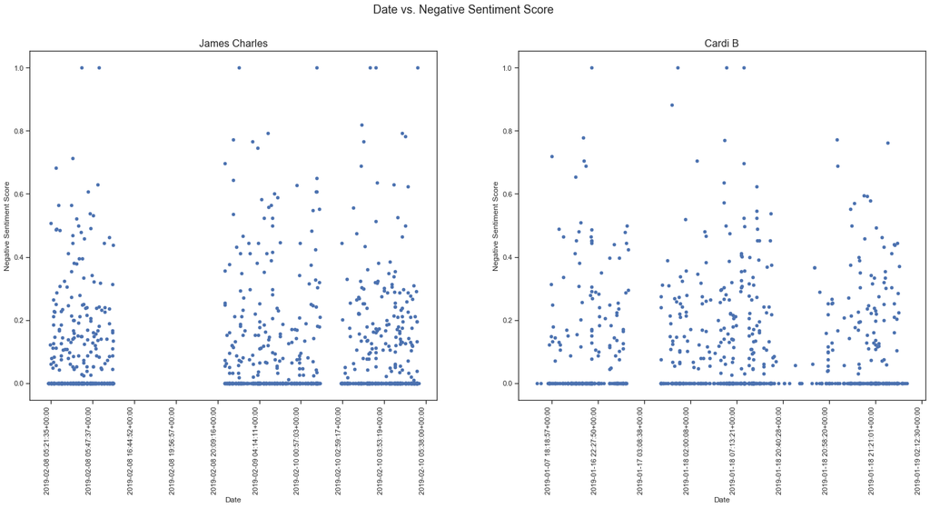

```python
fig, axs = plt.subplots(ncols=2, figsize=(25,10))
fig.suptitle('Date vs. Negative Sentiment Score', fontsize=18)

ax1 = james_date.plot.scatter(x='new_date', y='neg', ax=axs[0])
ax2 = cardi_date.plot.scatter(x='new_date', y='neg', ax=axs[1])

ax1.set_title('James Charles', fontsize=16)
ax2.set_title('Cardi B', fontsize=16)

ax1.set_xticklabels(labels=james_date.date, rotation=90, ha='right')
ax2.set_xticklabels(labels=cardi_date.date, rotation=90, ha='right')

ax1.xaxis.set_major_locator(plt.MaxNLocator(10))
ax2.xaxis.set_major_locator(plt.MaxNLocator(10))

ax1.set_xlabel(xlabel='Date')
ax2.set_xlabel(xlabel='Date')
ax1.set_ylabel(ylabel='Negative Sentiment Score')
ax2.set_ylabel(ylabel='Negative Sentiment Score')
```

There is no linear relationship between date and negative sentiment. We cannot conclude that the negative sentiment of the celebrities' posts has changed.

Our first research question was, is cancel culture a negative phenomenon? After analyzing the sentiment of cancel culture tweets about James Charles and Cardi B as well as tweets from James Charles and Cardi B, we cannot conclude that cancel culture is a negative phenomenon. The highest sentiment category score was neutral when the sentiment scores by post for cancel culture tweets and celebrity tweets were averaged. There is not enough evidence to suggest that cancel culture negatively influences the climate on Twitter. We looked at the cancel culture tweets and celebrity tweets over time from 1/1/2019 to 4/27/2020 and did not see a major change in the negative sentiment score over time. The next step would be to find the anger and negative emotion words in cancel culture tweets using LIWC to better analyze the negativity of these tweets. As we saw in the boxplots of negative sentiment score by post, there were a lot of outliers with high negative sentiment scores. Analyzing these posts with high negative sentiment scores by finding the anger and negative-emotion words in the posts would be beneficial to our analysis. Our follow-up question was, are there any positive aspects to cancel culture? Again, given the average high neutrality score of the cancel-culture and celebrity tweets, we cannot conclude that there are any positive aspects to cancel culture. To analyze the positivity of cancel culture tweets further, we would analyze posts containing words in the positive emotion category using LIWC.

#### Our next research question is: does being canceled significantly hurt a celebrity's following and status? We plan to analyze this is through likes and comments on the celebrities' YouTube videos, and comments on the celebrities' Instagram posts.

### Part 2: YouTube

```python
from selenium import webdriver
from selenium.webdriver.common.by import By
from selenium.common.exceptions import NoSuchElementException
from selenium.webdriver.support import expected_conditions as EC
from selenium.webdriver.support.ui import WebDriverWait
from selenium.webdriver.common.keys import Keys
import os
import datetime
import time
from bs4 import BeautifulSoup
import pprint
from collections import OrderedDict
```

```python
no_of_serps = 1
search_results_path = "web_scraping"

# creating driver to scrape from
def create_driver():
    chrome_options = webdriver.ChromeOptions()
    chrome_options.add_argument("--incognito")
    driver = webdriver.Chrome('/Users/allisondesantis/Documents/dsc/chromedriver', options=chrome_options)
    return driver

# closing driver
def teardown_driver(driver):
    driver.quit()

# tool to check if classes exist
def check_exists_by_class(browser, class_path):
    try:
        browser.find_element_by_class_name(class_path)

    except NoSuchElementException:
        return False
    return True
```

```python
# the number of scrolldowns in the search results page to get more results
scrolldown_count = 2
# time in seconds to wait till the reults load after a scrolldown
scrolldown_results_waiting_time = 4

# scraping title from youtube video
def get_video_title(soup):
    title = soup.find("h1",{'class':'title style-scope ytd-video-primary-info-renderer'})
    title = title.find("yt-formatted-string",{'class':'style-scope ytd-video-primary-info-renderer'}).get_text()
    return title

# scrapes description from youtube video
def get_description(soup):
    description = soup.find("div",{'id':'description','class':'style-scope ytd-video-secondary-info-renderer'})
    description = description.find("yt-formatted-string",{'class':'style-scope yt-formatted-string'})
    if (description is None):
        description = "NA"
    else:
        description = description.get_text()
    return description

# scrapes username from youtube video
def get_uploader_name(soup):
    name_uploader = soup.find("div",{'id':'upload-info','class':"style-scope ytd-video-owner-renderer"})
    name_uploader = name_uploader.find("a",{'class':'yt-simple-endpoint style-scope yt-formatted-string'}).get_text()
    return name_uploader

# scrapes current views from video
def get_views(soup):
    view = soup.find("span",{'class':'view-count style-scope yt-view-count-renderer'})
    if (view is None):
        view = 0
    else:
        view = view.get_text().split()[0]
    return view

# scrapes date from video
def get_date(soup):
    date = soup.find("div",{'id':'date','class':'style-scope ytd-video-primary-info-renderer'})
    date = date.find("yt-formatted-string",{'class':'style-scope ytd-video-primary-info-renderer'}).get_text()
    return date

# scrapes likes from video
def get_likes(soup):
    likes = soup.find("ytd-sentiment-bar-renderer",{'id':'sentiment','class':"style-scope ytd-video-primary-info-renderer"})
    likes = likes.find("paper-tooltip")
    likes = likes.find('div', {'id': "tooltip"}).get_text()
    likes = likes.rstrip("\n")
    likes = likes.lstrip("\n")
    return likes

#scrapes recommended videos from current video
def get_video_recommendations(soup):
    up_next = {}
    video_recommendations = {}
    block = soup.find_all("a",{'class':'yt-simple-endpoint style-scope ytd-compact-video-renderer'})
    up_next['title'] = block[0].find("span",{'class':'style-scope ytd-compact-video-renderer'}).get('title')
    up_next['url'] = block[0].get('href')
    for i in range(1, len(block)):
        recommendation = {}
        recommendation['title'] = block[i].find("span",{'class':'style-scope ytd-compact-video-renderer'}).get('title')
        recommendation['url'] = block[i].get('href')
        video_recommendations[str(i)] = recommendation
    return up_next,video_recommendations
```

```python
def get_video_metadata(url):
    browser = create_driver()
    browser.get(url)
    time.sleep(5)
    browser.refresh()
    time.sleep(5)
    #toggle autoplay button is its pressed
    auto_play_button = browser.find_element_by_xpath("//*[@id='toggle']").get_attribute("aria-pressed")
    if auto_play_button == 'true':
        WebDriverWait(browser, 20).until(EC.element_to_be_clickable((By.XPATH, '//*[@id="toggle"]/div[1]'))).click()

    # scroll down to end of page to get more results
    html_body = browser.find_element_by_tag_name('html')
    # allows comments to load

    for i in range(0,4):
        for i in range(5):
            html_body.send_keys(Keys.ARROW_DOWN)
        time.sleep(2)
        html_body.send_keys(Keys.END)
        time.sleep(4)

    html = browser.page_source
    soup = BeautifulSoup(html, "lxml")

    # organizes data into data frame with each comment
    df = pd.DataFrame(columns=["Uploader","Title", "Date", "Views", "Likes/Dislikes","Comments"])

    i=0
    for item in browser.find_elements_by_class_name("ytd-comment-thread-renderer"):
        df.loc[i] = [get_uploader_name(soup), get_video_title(soup), get_date(soup), get_views(soup), get_likes(soup), item.text]
        i = i+1

    #close driver
    teardown_driver(browser)
    return df;
```

Scraping 3 videos from each cancel case. One before incident, one during, and one after. Date is recorded to keep track of the timeline.

### Scraping 3 James Charles videos:

```python
# scraping 3 james charles videos:
james = get_video_metadata("https://www.youtube.com/watch?v=uFvtCUzfyL4")
```

```python
# got 100 comments
james[james['Comments'].str.contains("REPLY")]
```

```python
james = james.append(get_video_metadata("https://www.youtube.com/watch?v=cxGDMR05gL0"))
```

```python
# got 100 more comments
james[james['Comments'].str.contains("REPLY")]
```

```python
james = james.append(get_video_metadata("https://www.youtube.com/watch?v=eIC5YOR8gtY"))
```

```python
# got 300!!
cleanerJames = james[james['Comments'].str.contains("REPLY")]
cleanerJames
```

### Scraping 3 Cardi B videos:

```python
# got 120 comments
cardi = (get_video_metadata("https://www.youtube.com/watch?v=27z5Mu1hbJA"))
cleanerCardi = cardi[cardi['Comments'].str.contains("REPLY")]
cleanerCardi
```

```python
# got 135 comments
cardi = cardi.append(get_video_metadata("https://www.youtube.com/watch?v=xTlNMmZKwpA"))
cleanerCardi = cardi[cardi['Comments'].str.contains("REPLY")]
cleanerCardi
```

```python
# got 100 comments
cardi = cardi.append(get_video_metadata("https://www.youtube.com/watch?v=cJc7xWJbwJw"))
cleanerCardi = cardi[cardi['Comments'].str.contains("REPLY")]
cleanerCardi
```

### merging all artists to one dataframe

```python
df = cleanerJames.append(cleanerCardi)
df["Likes/Dislikes"] = df["Likes/Dislikes"].replace('\n','', regex=True)
# reset index and dropping James comment on own video
df = df.iloc[1:,:]
df = df.reset_index().drop_duplicates( keep='last')
#dropping old index column
df = df.iloc[:,1:]
```

### Breaking comments column into respective parts

```python
def splitMultiple(mickle):
    data = mickle.split('\n')
    info = []
    info.append(data[0])
    info.append(data [1])
    comment = ""
    for line in data[2:-2]:
        comment+=line+'\n'
    info.append(comment)
    info.append(data[-2])
    if info[2] == "":
        info[2]=info[3]
        info[3] =0
    return info
```

```python
l=pd.DataFrame(list(df.Comments.map(splitMultiple)), columns=['Comment_User','Comment_Date','Comment','Comment_Likes'])
```

### Replacing old comments column with new comment detail colums

```python
df = pd.concat([df.iloc[:,:-1],l], axis=1)
```

```python
import datetime
from dateutil.relativedelta import relativedelta

def get_past_date(str_days_ago):
    TODAY = datetime.date.today()
    splitted = str_days_ago.split()
    if len(splitted) == 1 and splitted[0].lower() == 'today':
        return str(TODAY.isoformat())
    elif len(splitted) == 1 and splitted[0].lower() == 'yesterday':
        date = TODAY - relativedelta(days=1)
        return str(date.isoformat())
    elif splitted[1].lower() in ['hour', 'hours', 'hr', 'hrs', 'h']:
        date = datetime.datetime.now() - relativedelta(hours=int(splitted[0]))
        return str(date.date().isoformat())
    elif splitted[1].lower() in ['day', 'days', 'd']:
        date = TODAY - relativedelta(days=int(splitted[0]))
        return str(date.isoformat())
    elif splitted[1].lower() in ['wk', 'wks', 'week', 'weeks', 'w']:
        date = TODAY - relativedelta(weeks=int(splitted[0]))
        return str(date.isoformat())
    elif splitted[1].lower() in ['mon', 'mons', 'month', 'months', 'm']:
        date = TODAY - relativedelta(months=int(splitted[0]))
        return str(date.isoformat())
    elif splitted[1].lower() in ['yrs', 'yr', 'years', 'year', 'y']:
        date = TODAY - relativedelta(years=int(splitted[0]))
        return str(date.isoformat())
    else:
        return str(TODAY.isoformat())
```

### Fixing comment_date

```python
df.Comment_Date=df.Comment_Date.map(get_past_date)
```

### fixing comment_likes

```python
def to_thousands(likes):
    if type(likes) is str:
        if "www.youtube.com" in likes:
            return 0
        if "K" in likes:
            a = likes.replace("K","")
            temp = 1000*float(a)
            return int(temp)
        return likes
```

```python
df.Comment_Likes=df.Comment_Likes.map(to_thousands)
df.Comment_Likes = pd.to_numeric(df.Comment_Likes,errors='coerce')
```

```python
df.to_csv('betterYoutube.csv')
```

# James Charles Analysis

```python
df = pd.read_csv('betterYoutubeOld.csv')
analyzer = SentimentIntensityAnalyzer()
sentences = df.Comment.tolist()
vs = []
for sentence in sentences:
    vs.append(analyzer.polarity_scores(sentence))
df = df.iloc[:,1:]
df
```

|  | Uploader | Title | Date | Views | Likes/Dislikes | Comment_User | Comment_Date | Comment | Comment_Likes |
| --- | --- | --- | --- | --- | --- | --- | --- | --- | --- |
| 0 | James Charles | No More Lies | May 18, 2019 | 49,867,732 | 2,456,577 / 610,400 | rachelskyscraper | 2019-11-28 | This has got to be the biggest uno reverse car... | 36000.0 |
| 1 | James Charles | No More Lies | May 18, 2019 | 49,867,732 | 2,456,577 / 610,400 | ` katiexvia ` | 2020-03-28 | can't believe that James literally handled thi... | 12000.0 |
| 2 | James Charles | No More Lies | May 18, 2019 | 49,867,732 | 2,456,577 / 610,400 | pizza_lover | 2020-04-21 | ik this is almost a year old, but James, serio... | 1300.0 |
| 3 | James Charles | No More Lies | May 18, 2019 | 49,867,732 | 2,456,577 / 610,400 | colton howard | 2020-03-28 | how is this 11 months ago it literally feels l... | 4800.0 |
| 4 | James Charles | No More Lies | May 18, 2019 | 49,867,732 | 2,456,577 / 610,400 | The tea Is hot | 2020-04-07 | The fact that this video didn’t have a single ... | 1100.0 |
| ... | ... | ... | ... | ... | ... | ... | ... | ... | ... |
| 690 | Cardi B | Cardi B - Press [Official Music Video] | Premiered Jun 26, 2019 | 70,298,597 | 1,501,301 / 153,913 | Brianna Lynne | 2019-07-28 | YouTube: No sexual related/nudity permitted. \... | 2500.0 |
| 691 | Cardi B | Cardi B - Press [Official Music Video] | Premiered Jun 26, 2019 | 70,298,597 | 1,501,301 / 153,913 | K0 K0 | 2020-04-27 | Killed it 🔥\n | 1.0 |
| 692 | Cardi B | Cardi B - Press [Official Music Video] | Premiered Jun 26, 2019 | 70,298,597 | 1,501,301 / 153,913 | Cesco 00 | 2020-04-27 | 2:04 If Annalise Keating were a rapper. | 0.0 |
| 693 | Cardi B | Cardi B - Press [Official Music Video] | Premiered Jun 26, 2019 | 70,298,597 | 1,501,301 / 153,913 | Eliza | 2020-04-07 | Ah ok I kinda expected that from Cardi\n | 1.0 |
| 694 | Cardi B | Cardi B - Press [Official Music Video] | Premiered Jun 26, 2019 | 70,298,597 | 1,501,301 / 153,913 | C J | 2020-04-25 | I show this to my dog \n | NaN |

695 rows × 9 columns

```python
vader = pd.DataFrame(vs)
```

```python
analysisdf = pd.concat([df,vader], axis=1)
analysisdf
James = analysisdf.loc[analysisdf['Uploader'] == "James Charles"]
Cardi = analysisdf.loc[analysisdf['Uploader'] == "Cardi B"]
```

```python
James_before = analysisdf.loc[analysisdf['Title'] == "FALL FIRST IMPRESSIONS MAKEUP TUTORIAL"]
James_during = analysisdf.loc[analysisdf['Title'] == "No More Lies"]
James_after = analysisdf.loc[analysisdf['Title'] == "Fans Pick My Makeup On Zoom!"]
```

```python
James_before_ratio = James_before.iloc[0,4].split("/")
James_during_ratio = James_during.iloc[0,4].split("/")
James_after_ratio = James_after.iloc[0,4].split("/")

James_likes = [int(James_before_ratio[0].replace(" ","").replace(",","")),\
               int(James_during_ratio[0].replace(" ","").replace(",","")),\
               int(James_after_ratio[0].replace(" ","").replace(",",""))]
James_dislikes = [int(James_before_ratio[1].replace(" ","").replace(",","")),\
                  int(James_during_ratio[1].replace(" ","").replace(",","")),\
                  int(James_after_ratio[1].replace(" ","").replace(",",""))]
James_views = [int(James_before.iloc[1,3].replace(",","")), \
               int(James_during.iloc[1,3].replace(",","")),\
               int(James_after.iloc[1,3].replace(",",""))]
```

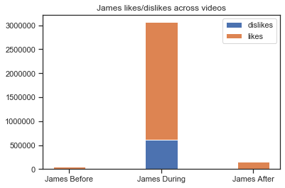

```python
fig, ax = plt.subplots()

labels = ['James Before','James During','James After']

ax.bar(labels, James_dislikes, .35, label='dislikes')
ax.bar(labels, James_likes, .35, bottom=James_dislikes, label='likes')

ax.set_title('James likes/dislikes across videos')
ax.legend()

plt.show()
```

#### This stacked bar plot shows the engagement in James Charles videos went way up during his cancel controversy, yet he still had proportionally more likes

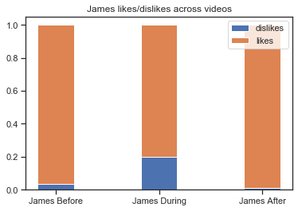

```python
totallikesbefore = James_dislikes[0]+James_likes[0]
totallikesduring = James_dislikes[1]+James_likes[1]
totallikesafter = James_dislikes[2]+James_likes[2]
total = [totallikesbefore,totallikesduring,totallikesafter]

dis= [James_dislikes[x]/total[x] for x in range(3)]
lik=[James_likes[x]/total[x] for x in range(3)]

fig, ax1 = plt.subplots()

labels = ['James Before','James During','James After']

ax1.bar(labels, dis, .35, label='dislikes')
ax1.bar(labels, lik, .35, bottom=dis,label='likes')

ax1.set_title('James likes/dislikes across videos')
ax1.legend()

plt.show()
```

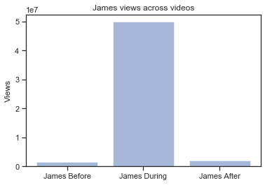

```python
plt.bar(labels, James_views, align='center', alpha=0.5)
plt.xticks(labels)
plt.ylabel('Views')
plt.title('James views across videos')

plt.show()
```

#### This bar plot shows that the views during James controversy skyrocketed up to almost 50 million, and again restabalized after. This shows that the controversey did not have a substantial effect on his overall views positively or negatively.

## Sentiment analysis:

```python
James_before["compound"].mean()
```

```
0.45961299999999994
```

```python
James_during["compound"].mean()
```

```
0.09915757575757576
```

```python
James_after["compound"].mean()
```

```
0.30840249999999997
```

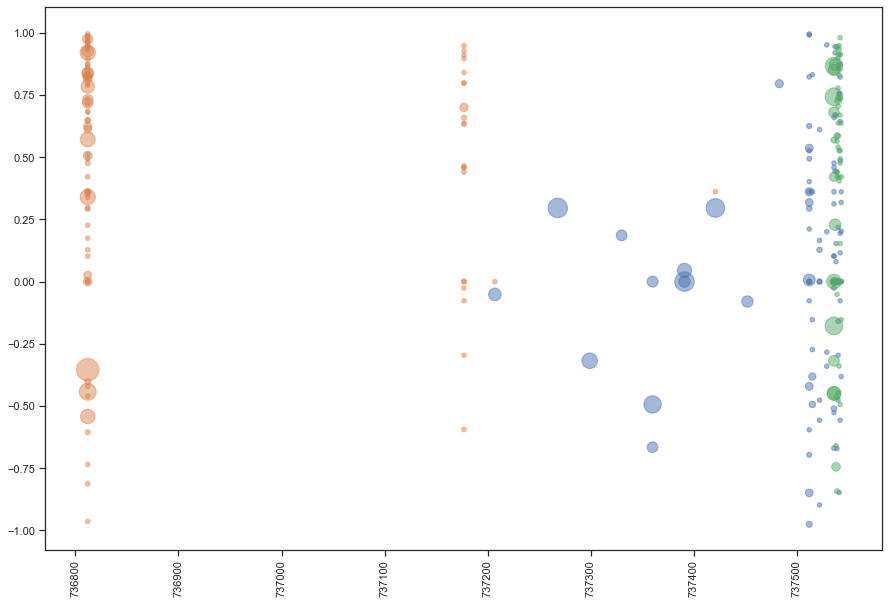

```python
James_before['date_ordinal'] = pd.to_datetime(James_before['Comment_Date']).apply(lambda date: date.toordinal())
James_during['date_ordinal'] = pd.to_datetime(James_during['Comment_Date']).apply(lambda date: date.toordinal())
James_after['date_ordinal'] = pd.to_datetime(James_after['Comment_Date']).apply(lambda date: date.toordinal())

plt.figure(figsize=(15,10))
size1=(James_during["Comment_Likes"]/(James_during["Comment_Likes"].mean()))*30+20
plt.scatter(James_during["date_ordinal"], James_during["compound"], s=size1, alpha=0.5)
size2=(James_before["Comment_Likes"]/(James_before["Comment_Likes"].mean()))*30+20
plt.scatter(James_before["date_ordinal"], James_before["compound"], s=size2, alpha=0.5)
size3=(James_after["Comment_Likes"]/(James_after["Comment_Likes"].mean()))*30+20
plt.scatter(James_after["date_ordinal"], James_after["compound"], s=size3, alpha=0.5)
plt.xticks(rotation=90)
```

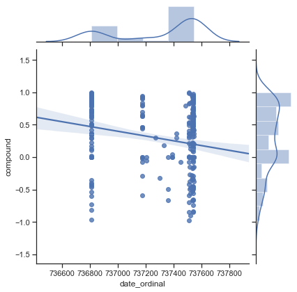

```python
James['date_ordinal'] = pd.to_datetime(James['Comment_Date']).apply(lambda date: date.toordinal())

sns.jointplot(x='date_ordinal', y='compound', kind="reg", data=James)
```

# Cardi Analysis

```python
Cardi_before = analysisdf.loc[analysisdf['Title'] == "Cardi B - Leave That Bitch Alone (Skit) (Audio) ft. Justvlad"]
Cardi_during = analysisdf.loc[analysisdf['Title'] == "Cardi B, Bad Bunny & J Balvin - I Like It [Official Music Video]"]
Cardi_after = analysisdf.loc[analysisdf['Title'] == "Cardi B - Press [Official Music Video]"]
```

Setting up likes, dislikes, and views for bar plots

```python
Cardi_before_ratio = Cardi_before.iloc[1,4].split("/")
Cardi_during_ratio = Cardi_during.iloc[1,4].split("/")
Cardi_after_ratio = Cardi_after.iloc[1,4].split("/")

Cardi_likes = [int(Cardi_before_ratio[0].replace(" ","").replace(",","")),int(Cardi_during_ratio[0].replace(" ","").replace(",","")),int(Cardi_after_ratio[0].replace(" ","").replace(",",""))]
Cardi_dislikes = [int(Cardi_before_ratio[1].replace(" ","").replace(",","")),int(Cardi_during_ratio[1].replace(" ","").replace(",","")),int(Cardi_after_ratio[1].replace(" ","").replace(",",""))]

Cardi_views = [int(Cardi_before.iloc[1,3].replace(",","")), int(Cardi_during.iloc[1,3].replace(",","")),int(Cardi_after.iloc[1,3].replace(",",""))]
```

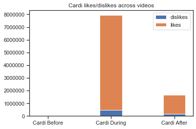

```python
fig, ax = plt.subplots()

labels = ['Cardi Before','Cardi During','Cardi After']

ax.bar(labels, Cardi_dislikes, .35, label='dislikes')
ax.bar(labels, Cardi_likes, .35, bottom=Cardi_dislikes, label='likes')

ax.set_title('Cardi likes/dislikes across videos')
ax.legend()

plt.show()
```

```python
Cardi_before_ratio
```

```
['      1,645 ', ' 155    ']
```

#### This stacked barplot of likes/dislikes on Cardi's videos is not very effective due to her video during her controversy reaching 1.1 billion views. It completely shrinks her likes/comments from before. This could also be just her natural rise to fame. I've printed her likes/dislikes before.

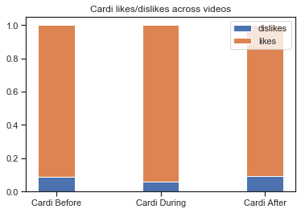

```python
totallikesbefore = Cardi_dislikes[0]+Cardi_likes[0]
totallikesduring = Cardi_dislikes[1]+Cardi_likes[1]
totallikesafter = Cardi_dislikes[2]+Cardi_likes[2]
total = [totallikesbefore,totallikesduring,totallikesafter]

dis= [Cardi_dislikes[x]/total[x] for x in range(3)]
lik=[Cardi_likes[x]/total[x] for x in range(3)]

fig, ax1 = plt.subplots()

labels = ['Cardi Before','Cardi During','Cardi After']

ax1.bar(labels, dis, .35, label='dislikes')
ax1.bar(labels, lik, .35, bottom=dis,label='likes')

ax1.set_title('Cardi likes/dislikes across videos')
ax1.legend()

plt.show()
```

#### A proportional barplot better shows that Cardi's like/dislikes ratio were not affected by her controversy.

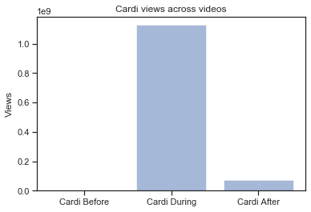

```python
plt.bar(labels, Cardi_views, align='center', alpha=0.5)
plt.xticks(labels)
plt.ylabel('Views')
plt.title('Cardi views across videos')

plt.show()
```

#### This barplot of her views show the extreme change in views from her popular song

## Sentiment analysis:

```python
Cardi_before["compound"].mean()
Cardi_during["compound"].mean()
Cardi_after["compound"].mean()
```

```
0.06415874999999999
```

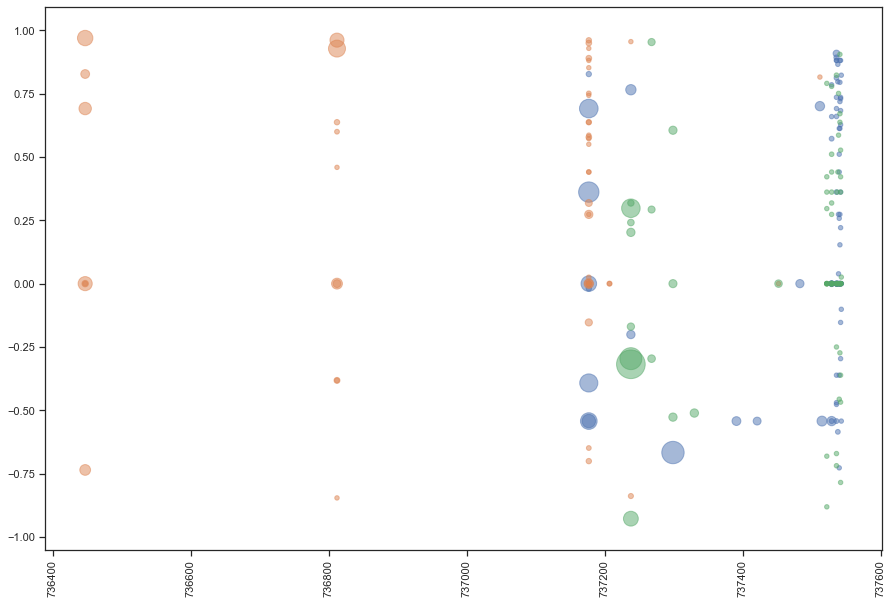

```python
Cardi_before['date_ordinal'] = pd.to_datetime(Cardi_before['Comment_Date']).apply(lambda date: date.toordinal())
Cardi_during['date_ordinal'] = pd.to_datetime(Cardi_during['Comment_Date']).apply(lambda date: date.toordinal())
Cardi_after['date_ordinal'] = pd.to_datetime(Cardi_after['Comment_Date']).apply(lambda date: date.toordinal())

plt.figure(figsize=(15,10))
size=(Cardi_during["Comment_Likes"]/(Cardi_during["Comment_Likes"].mean()))*30+20
plt.scatter(Cardi_during["date_ordinal"], Cardi_during["compound"], s=size,alpha=0.5)
size2=(Cardi_before["Comment_Likes"]/(Cardi_before["Comment_Likes"].mean()))*30+20
plt.scatter(Cardi_before["date_ordinal"], Cardi_before["compound"], s=size2, alpha=0.5)
size3=(Cardi_after["Comment_Likes"]/(Cardi_after["Comment_Likes"].mean()))*30+20
plt.scatter(Cardi_after["date_ordinal"], Cardi_after["compound"], s=size3, alpha=0.5)
plt.xticks(rotation=90)
```

#### Again, the above scatter plot shows the sentiment of the comments on each video organized by color. Darker areas show where the sentiment on the comments were more densely concentrated. It's not clear looking at this graph whether her sentiment went up or down

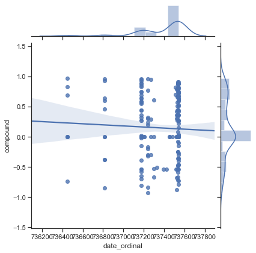

```python
Cardi['date_ordinal'] = pd.to_datetime(Cardi['Comment_Date']).apply(lambda date: date.toordinal())

sns.jointplot(x='date_ordinal', y='compound',kind="reg",data=Cardi)
```

#### Finally, this plot adds the comment and sentiment distibutions to the previous graph. It shows that although her overall sentiment is fairly centered, there is a peak below neutral.

### Part 3: Instagram

Cannot run without authentication

```python
import csv
import itertools
import json
import instaloader

# Opening keys from json files
def loadKeys(key_file):
    with open("keys.json") as f:
        key_dict = json.load(f)
    return key_dict["user"], key_dict["password"]

# Loading instgram account to go to account
KEY_FILE = "key.json"
user, password = loadKeys(KEY_FILE)

# Get instance
L = instaloader.Instaloader(download_comments = True)

# Login or load session
L.login(user, password)        # (login)
```

```python
# Geting comments and likes from a post of celebrity
def getCommentsAndLikes(name, postNumber, comments):

    # Getting profile name
    commentCount = comments
    # Name of profile
    pro = name

    # Loading profile name and their page
    profile = instaloader.Profile.from_username(L.context, pro)

    # Creating List to track comments and the likes of those comments
    likes = []
    comments = []
    dates = []
    print("Collecting {} comments and likes\n\n".format(pro))

    # Iterating over each post of the profile
    for post in itertools.islice(profile.get_posts(), postNumber, postNumber + 1):
        # Iterating over each comment
        for comment in itertools.islice(post.get_comments(), 250, 250 + commentCount):

            # Getting a comment and corresponding likes from different posts
            likes.append(comment.likes_count)
            comments.append(comment.text)
            dates.append(comment.created_at_utc)
    return dates, comments, likes
```

```python
# Creating a table of canceled people
def createTable(canceled, posts, totalComments):
    df = pd.DataFrame()
    for post in posts:
        df["Post " + str(post) + ": "+ canceled + " Date"], \
            df["Post " + str(post) + ": "+ canceled + " Comments"], \
            df["Post " + str(post) + ": " + canceled + " Likes"] = \
        getCommentsAndLikes(canceled, post, totalComments)

    # Making CSV file
    df.to_csv(canceled + "Canceled.csv")
    # Returning dataframe
    return df
```

```python
# Testing Function when given lists of artist
# Scans 5 most recent posts for a total of 500 comments
cardiBPosts = [ 460, 426, 390 ]
charlesPosts = [114, 100, 84]
PROFILE = [("jamescharles", charlesPosts), ("iamcardib", cardiBPosts)]

for celebs in PROFILE:
    createTable(celebs[0], celebs[1], 250)
```

```python
# Getting rid of extra data
def fixDate(date):
    date = date.split()
    return date[0]
```

```python
# Fixing column
cardiData = pd.read_csv("iamcardibCanceled.csv")
cardiData = cardiData.drop(columns = 'Unnamed: 0')
```

```python
# Fixing date data
cardiData["Post 460: iamcardib Date"] = \
cardiData["Post 460: iamcardib Date"].map(fixDate)
cardiData["Post 426: iamcardib Date"] = \
cardiData["Post 426: iamcardib Date"].map(fixDate)
cardiData["Post 390: iamcardib Date"] = \
cardiData["Post 390: iamcardib Date"].map(fixDate)
```

```python
# Creating new csv
cardiData.to_csv("cleaned-iamcardibCanceled.csv")
jamesData = pd.read_csv("jamescharlesCanceled.csv")
jamesData = jamesData.drop(columns = 'Unnamed: 0')
```

```python
# Fixing date data
jamesData["Post 114: jamescharles Date"] = jamesData["Post 114: jamescharles Date"].map(fixDate)
jamesData["Post 100: jamescharles Date"] = jamesData["Post 100: jamescharles Date"].map(fixDate)
jamesData["Post 84: jamescharles Date"] = jamesData["Post 84: jamescharles Date"].map(fixDate)
```

```python
# Creating new csv
jamesData.to_csv("cleaned-jamescharlesCanceled.csv")
```

### Adding Sentiment Analysis To Tables

```python
jamesData = pd.read_csv("cleaned-jamescharlesCanceled.csv", index_col=0)
cardiData = pd.read_csv("cleaned-iamcardibCanceled.csv", index_col=0)
```

```python
#Using vader to do sentiment analysis for james charles data
analyzer = SentimentIntensityAnalyzer()
sentimentOne = []
sentimentTwo = []
sentimentThree = []
for x in range(250):
    sentimentOne.append(analyzer.polarity_scores(jamesData.iloc[x, 1]).get("compound"))
    sentimentTwo.append(analyzer.polarity_scores(jamesData.iloc[x, 4]).get("compound"))
    sentimentThree.append(analyzer.polarity_scores(jamesData.iloc[x, 7]).get("compound"))
jamesData["Post 114: Sentiment"] = pd.Series(sentimentOne)
jamesData["Post 100: Sentiment"] = pd.Series(sentimentTwo)
jamesData["Post 84: Sentiment"] = pd.Series(sentimentThree)
jamesData = jamesData[['Post 114: jamescharles Date', 'Post 114: jamescharles Comments', 'Post 114: jamescharles Likes', 'Post 114: Sentiment',
    'Post 100: jamescharles Date', 'Post 100: jamescharles Comments', 'Post 100: jamescharles Likes', 'Post 100: Sentiment',
    'Post 84: jamescharles Date', 'Post 84: jamescharles Comments','Post 84: jamescharles Likes', 'Post 84: Sentiment']]

jamesData
```

|  | Post 114: jamescharles Date | Post 114: jamescharles Comments | Post 114: jamescharles Likes | Post 114: Sentiment | Post 100: jamescharles Date | Post 100: jamescharles Comments | Post 100: jamescharles Likes | Post 100: Sentiment | Post 84: jamescharles Date | Post 84: jamescharles Comments | Post 84: jamescharles Likes | Post 84: Sentiment |
| --- | --- | --- | --- | --- | --- | --- | --- | --- | --- | --- | --- | --- |
| 0 | 2019-09-02 | I thought danny codoy was a woman | 1 | 0.0000 | 2019-07-05 | Beautiful even without makeup | 0 | 0.5994 | 2019-08-15 | Wolf wolf | 1 | 0.0000 |
| 1 | 2019-09-02 | @kristenstone_ wtf if he can do this I can surely | 2 | -0.2263 | 2019-07-05 | Eee kot xezele mujik bolll 💪💪💪 | 1 | 0.0000 | 2019-08-16 | The new color of your hair is matching this ha... | 1 | -0.7003 |
| 2 | 2019-09-02 | 😱😘 | 0 | -0.4588 | 2019-07-05 | 😮😮😮 | 0 | 0.0000 | 2019-08-16 | Wolf wolf | 1 | 0.0000 |
| 3 | 2019-09-02 | Yaaaaas | 0 | 0.0000 | 2019-07-05 | That nose tho | 14 | 0.0000 | 2019-08-16 | I saw it | 1 | 0.0000 |
| 4 | 2019-09-03 | Runway queen @jamescharles | 0 | 0.0000 | 2019-07-05 | You look WAYYY better when your YOU. You look ... | 3 | 0.7717 | 2019-08-17 | Omg Idc abou the video but you’re such a cutie... | 3 | 0.9366 |
| ... | ... | ... | ... | ... | ... | ... | ... | ... | ... | ... | ... | ... |
| 245 | 2019-07-11 | Work that cape sis | 0 | 0.0000 | 2019-05-26 | my mullet is better | 0 | 0.4404 | 2019-07-17 | I do my hommon puts it on for me she woves you... | 0 | 0.0000 |
| 246 | 2019-07-11 | Omg u rocked the fashion walk | 0 | 0.0000 | 2019-05-26 | Safety pin in ear? 🧷 | 1 | 0.6808 | 2019-07-17 | Cuteeeeee😍😍😍 | 0 | 0.8402 |
| 247 | 2019-07-11 | U go sister squad king 👑 | 2 | 0.0000 | 2019-05-26 | So pretty💜 | 0 | 0.5413 | 2019-07-18 | I have a pingüino hat simular to that. | 0 | 0.0000 |
| 248 | 2019-07-11 | 😂😂😂 | 1 | 0.8271 | 2019-05-26 | Your met gala outfit still hurts me | 2 | -0.4767 | 2019-07-18 | Its random. No one want u gaylirs | 0 | -0.3447 |
| 249 | 2019-07-11 | 😊😊😊🔥🤣😂 | 1 | 0.9670 | 2019-05-26 | Your ear is pierced | 1 | 0.0000 | 2019-07-18 | how do you nose countour*** ? ( ir however you... | 0 | 0.0000 |

250 rows × 12 columns

```python
# Using VADER to do sentiment analysis for Cardi B data
analyzer = SentimentIntensityAnalyzer()
sentimentOne = []
sentimentTwo = []
sentimentThree = []
for x in range(250):
    sentimentOne.append(analyzer.polarity_scores(cardiData.iloc[x, 1]).get("compound"))
    sentimentTwo.append(analyzer.polarity_scores(cardiData.iloc[x, 4]).get("compound"))
    sentimentThree.append(analyzer.polarity_scores(cardiData.iloc[x, 7]).get("compound"))
cardiData["Post 460: Sentiment"] = pd.Series(sentimentOne)
cardiData["Post 426: Sentiment"] = pd.Series(sentimentTwo)
cardiData["Post 390: Sentiment"] = pd.Series(sentimentThree)

cardiData = cardiData[['Post 460: iamcardib Date', 'Post 460: iamcardib Comments', 'Post 460: iamcardib Likes', 'Post 460: Sentiment',
    'Post 426: iamcardib Date', 'Post 426: iamcardib Comments', 'Post 426: iamcardib Likes', 'Post 426: Sentiment',
    'Post 390: iamcardib Date', 'Post 390: iamcardib Comments', 'Post 390: iamcardib Likes', 'Post 390: Sentiment']]

cardiData
```

|  | Post 460: iamcardib Date | Post 460: iamcardib Comments | Post 460: iamcardib Likes | Post 460: Sentiment | Post 426: iamcardib Date | Post 426: iamcardib Comments | Post 426: iamcardib Likes | Post 426: Sentiment | Post 390: iamcardib Date | Post 390: iamcardib Comments | Post 390: iamcardib Likes | Post 390: Sentiment |
| --- | --- | --- | --- | --- | --- | --- | --- | --- | --- | --- | --- | --- |
| 0 | 2019-03-10 22:40:34 | 😘😘😘😘😘😘😘 | 0 | 0.9559 | 2019-03-17 15:18:23 | Free the brim 😍😍❤️❤️❤️❤️ | 1 | 0.8519 | 2019-04-24 12:04:39 | ❤️ | 0 | 0.0000 |
| 1 | 2019-03-10 22:50:56 | @x.x.xmermaction T3erfi diri hka hhh 😂😂😂 | 0 | 0.8271 | 2019-03-17 15:22:54 | 😊😊😊😊😊😊 | 0 | 0.9872 | 2019-04-24 14:40:39 | The hairstyle is sick | 0 | -0.5106 |
| 2 | 2019-03-11 02:19:55 | A | 1 | 0.0000 | 2019-03-17 15:26:43 | And she’s Guyanese @iamcardib 🤪🤪 | 2 | 0.0000 | 2019-04-24 16:58:06 | I need that bag sis beautiful ❤️❤️❤️❤️❤️❤️❤️❤️... | 0 | 0.5994 |
| 3 | 2019-03-11 02:21:14 | @__khyam | 0 | 0.0000 | 2019-03-17 15:47:51 | queen | 0 | 0.0000 | 2019-04-24 17:24:48 | Love this look from head to toe boo!! @iamcardib | 0 | 0.6988 |
| 4 | 2019-03-11 02:29:50 | @iamthefirstking 👀 | 0 | 0.0000 | 2019-03-17 15:49:24 | And she’s a Pisces and Guyanese 😩😩 | 1 | -0.4939 | 2019-04-24 18:05:53 | I know ur feet has to be feeling really great ... | 1 | 0.9795 |
| ... | ... | ... | ... | ... | ... | ... | ... | ... | ... | ... | ... | ... |
| 245 | 2019-03-02 06:22:08 | 😍😍😍😍 | 0 | 0.9001 | 2019-03-15 12:18:08 | She is pretty .. Happy birthday Queen | 1 | 0.7845 | 2019-04-18 14:28:22 | Mommy shark💕 | 0 | 0.0000 |
| 246 | 2019-03-02 06:27:10 | Hair looks great | 0 | 0.6249 | 2019-03-15 12:22:09 | Happy birthday sweedy 💟 | 0 | 0.5719 | 2019-04-18 14:28:42 | 😍😍 | 0 | 0.7184 |
| 247 | 2019-03-02 07:08:51 | You got that Right Fuck Nikki hating ass | 0 | -0.8834 | 2019-03-15 12:24:52 | 🙌🙌🙌🙌 | 0 | 0.0000 | 2019-04-18 14:40:36 | Wow 🤗 | 1 | 0.7650 |
| 248 | 2019-03-02 07:57:24 | Hey who else smells that🤢🤢🤢 | 1 | 0.0000 | 2019-03-15 12:37:37 | Hi | 0 | 0.0000 | 2019-04-18 14:50:48 | 👏👏👏👏👏👏 | 0 | 0.0000 |
| 249 | 2019-03-02 09:40:35 | 😍🔥😂❤️ | 1 | 0.5423 | 2019-03-15 12:41:53 | @blackedbacon yo me siento esta negra cuando h... | 2 | -0.3182 | 2019-04-18 15:19:38 | 🔥💙 | 0 | -0.3400 |

250 rows × 12 columns

creating axis and means of sentiment analysis

```python
# Finding axis of the sentiment and each posts
cardiSentimentMean = [cardiData["Post 460: Sentiment"].mean(), \
                      cardiData["Post 426: Sentiment"].mean(), \
                      cardiData["Post 390: Sentiment"].mean()]
jamesSentimentMean = [jamesData["Post 114: Sentiment"].mean(), \
                      jamesData["Post 100: Sentiment"].mean(), \
                      jamesData["Post 84: Sentiment"].mean()]
cardiBPosts = ["Before (Post: 460)","During (Post: 426)", \
               "After (Post: 390)" ]
charlesPosts = ["Before (Post: 114)", "During (Post: 100)", \
                "After (Post: 84)"]
```

### Visualizing Cardi B Data

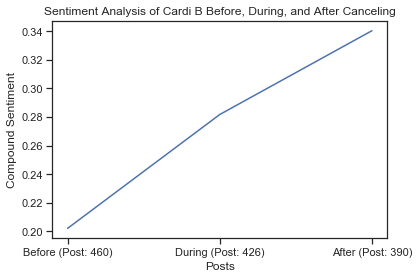

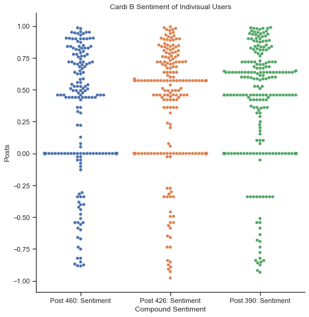

```python
# Visualing the mean change of sentiment for each post
ax = plt.plot(cardiBPosts, cardiSentimentMean)

plt.xlabel('Posts')
plt.ylabel('Compound Sentiment')
plt.title("Sentiment Analysis of Cardi B Before, During, and After Canceling")
plt.show()
# Visualizing 250 comments sentiments in different posts of cardi b
sns.set(style="ticks", color_codes=True)
cardiCat = cardiData.iloc[:,[3,7,11]]
plot = sns.catplot(data= cardiCat, kind="swarm", height = 7, aspect = 1)
plot.set(xlabel='Compound Sentiment', ylabel='Posts', title= "Cardi B Sentiment of Indivisual Users")
plt.show(plot)
```

### Visualizing James Charles Data

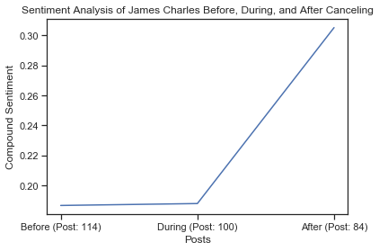

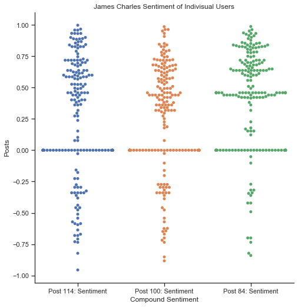

```python
# Visualing the mean change of sentiment for each post
plt.plot(charlesPosts, jamesSentimentMean)
plt.xlabel('Posts')
plt.ylabel('Compound Sentiment')
plt.title("Sentiment Analysis of James Charles Before, During, and After Canceling")
plt.show()
# Visualizing 250 comments sentiments in different posts of james charles
sns.set(style="ticks", color_codes=True)
jamesCat = jamesData.iloc[:,[3,7,11]]
jamesCat
plot = sns.catplot(data= jamesCat,kind="swarm", height = 7, aspect = 1)
plot.set(xlabel='Compound Sentiment', ylabel='Posts', title= "James Charles Sentiment of Indivisual Users")
plt.show(plot)
```

#### Is cancel culture a negative phenomenon? Are there any positive aspects?

From our visualiztions we can see that at least on Instagram, cancel culture results in the celebrity gaining more positive comments after being canceled for both Cardi B and James Charles. This may be because although they may be receiving hate from others, they can also be receiving more positive from fans that are trying to boost the celebrity in forms of positive comments.

#### Does being “canceled” on social media significantly hurt a celebrity or public figure’s following or status?

Along with gaining more positive support in terms of comments from fan we can also see from the scatter plots that overall negative comments seem to be less frequent than positive comments after a celebrity is cancelled. So in regards with the celebrities' statuses, they seems to be viewed more in a positive light after being cancelled.

### Conclusion

There is not enough data to conclude cancel culture is a negative phenomenon. On Twitter, the sentiment of the cancel culture tweets remained neutral, while on YouTube, the sentiment did become more negative over time. On Instagram, the sentiment increased in positivity over time. We cannot conclude that being canceled permanently damages a celebrity's reputation. To improve our analysis, we should take into account how types of engagement varies on Twitter, YouTube, and Instagram. For example, users might be more likely to post positive comments on Instagram than they are on Twitter which may have been why the sentiment of the Instagram data increased over time despite the celebrities being canceled. We should also take into account how cancel culture is different for social media influencers like James Charles than it is for artists like Cardi B. YouTube is James Charles' main platform, so it is not surprising that his sentiment decreased on YouTube when he was canceled. We should also use LIWC dictionary to find specific words that appear in our data.

#### References

https://www.merriam-webster.com/words-at-play/cancel-culture-words-were-watching

https://www.vox.com/culture/2019/12/30/20879720/what-is-cancel-culture-explained-history-debate

https://www.city-journal.org/cancel-culture